# Sqoop, Pig, Hive

Es posible que Hive no sea dueño de una tabla y aún así poder interactuar con los datos de la misma. Este tipo de tablas se ocupan cuando no queremos que Hive administre la vida de una tabla (o de los datos) y que por lo tanto al hacer `drop` no borremos los datos que están contenidos en la misma solo borraremos los metadatos de la tabla que se guardaron en el metastore.

Las tablas de Hive se llaman *managed* pero aún este tipo de tablas puede ser modificada por otras herramientas de hadoop como borrar directamente con comandos de hdfs, esto complica la adminstración de estos datos y Hive no tiene completo control aún de las tablas que le pertenecen. Por esta razón, si creemos que una tabla será compartida por varias herramientas de hadoop debemos declararla como externa para ser explícitos con su administración.

Para saber si una tabla es externa o administrada se ocupa el comando `DESCRIBE EXTENDED tablename`. Si decidimos crear una tabla externa ésta, debe estar en el dfs utilizado.

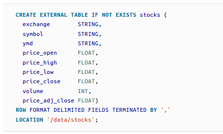

En el caso de borrar una tabla administrada por Hive tanto los datos como los metadatos son borrados, en el caso de tablas externas solo los metadatos son borrados.

- *Partitioning*

Hive puede administrar tablas -administradas y externas- particionadas. En las tablas administradas por Hive generar una partición hace que los datos se estructuren diferente en su almacenamiento, cada partición generará subcarpetas con la estrategia de **particionamiento** que vimos en HDFS -la que tiene un $=$ en el nombre de la carpeta.

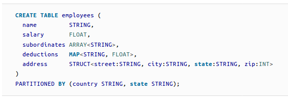

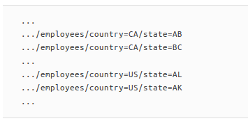

La razón más importante para hacer *partitioning* es para mejorar el desempeño de los queries y hacerlos más rápidos. Es posible generar un trabajo de MapReduce gigantesco si no se ocupan cláusulas `where` en lso queries, y es por esta razón que podemos limitar el comportamiento de Hive utilizando la configuración estricta o no estricta. En la configuración estricta Hive generará un error a los queries que no incluyen la cláusula `where` evitando generar trabajos de MapReduce muy grandes, en la configuración no estricta Hive permitirá que haya queries sin cláusula `where` generando trabajos de MapReduce muy costosos que no aprovechan la jerarquización de los datos hecha a través de particionamiento -if any-

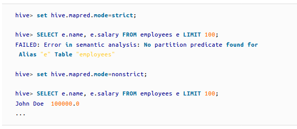

Es posible mostrar las particiones existentes en la base de datos a través del comando `SHOW PARTITIONS tablename;`, también es posible buscar por una partición en particular con el comando `SHOW PARTITIONS tablename PARTITION(key=value);`, también es posible obtener las particiones a través del comando `DESCRIBE EXTENDED tablename`

Para tablas externas no administradas por Hive se require de crear primero la tabla y luego alterarla para indicar la localización de cada partición de los datos

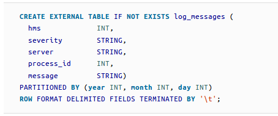

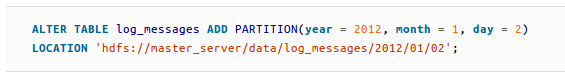

- `ALTER TABLE` permite modificar el nombre de una tabla, agregar y borrar columnas, cambiar el tipo de una columna, cambiar el nombre de una columna, reemplazar todas las columnas existentes por otras…

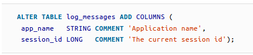

#### Manipulación de datos

En esta parte veremos cómo cargar datos a Hive. Debido a que en Hive no es posible insertar, borrar o modificar por renglón solo hay una manera de cargar datos a una tabla con `load`

- `LOAD DATA` Permite cargar los datos a una tabla de Hive. Si ocupamos la opción `LOCAL` Hive buscará los datos en un directorio localmente -en tu compu-, si no ponemos `LOCAL` hive busca el directorio en DFS. Con `LOCAL` Hive **copia** los datos locales a DFS, si no ponemos `local` Hive **mueve** los datos a HDFS.

Con `OVERWRITE` le decimos a Hive que queremos sobreescribir la tabla con estos nuevos datos, si no ponemos `OVERWRITE` Hive agregará datos a los ya existentes en esta tabla -if any-

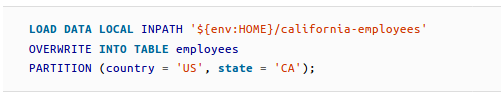

- `INSERT` Permite cargar datos a una tabla utilizando queries. Si ocupamos `INSERT OVERWRITE` borraremos el contenido de la tabla -o de la partición-, si ocupamos `INSERT INTO` agregaremos los datos a la tabla.

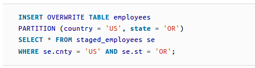

También es posible crear y cargar datos a la tabla creada al mismo tiempo:

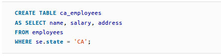

- Exportar datos: Para exportar datos de Hive a otras herramientas/formatos se puede simplemente copiar el directorio de DFS donde viven y ponerlos en el directorio de DFS deseado, o bien ocupar `INSERT ... DIRECTORY`. El número de archivos generados de esta operación dependerá del número de *reducers* que se tengan.

```
hdfs dfs -cp source_hive_path target_hdfs_path
```

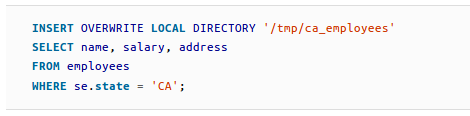

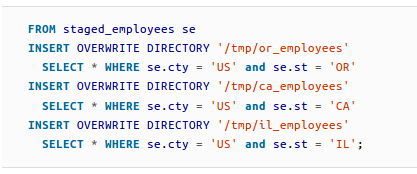

#### Queries

En Hive podemos ocupar el SQL estándar: select, from , group by, order by, having, joins, limit, etc.

- `ORDER BY` vs `SORT BY`. En hive existe la clásica función de `order by` a través de la cual es posible ordenar la salida de un query, sin embargo es importante destacar que `order by` requiere de tener todos los datos involucrados en el *query* para después ordenarlos (después de los *reducers*), con `sort by` hive ordena los resultados **por** *reducer* para que el ordenamiento final después de la etapa de *reduce* sea más eficiente -más rápida-.
- **Funciones**: Para ver todas las funciones disponibles en Hive puedes ocupar `show FUNCTIONS`, para ver la documentación de una función basta con poner `DESCRIBE FUNCTION`

`explode()`: Esta función permite iterar sobre un arreglo regresando cada elemento en la lista como un registro separado. Cuando ocupamos esta función solo es posible aplicarlo a una columna y no se pueden obtener más columnas en el mismo query (tengan o no explode :() para lograr hacer un explode con otras columnas en un select es necesario ocupar `LATERAL VIEW`. Por ejemplo: Queremos encontrar los nombres de empleados y subordinados por empleado, como una persona puede tener varios subordinados ocuparemos `explode`

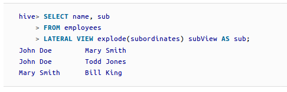

* Es necesario hacer un alias a la vista creada y al campo generado con el explode

**UDF**

Al igual que con Pig, en Hive es posible que nosotros definamos nuestras propias funciones -UDF- y es posible que las definamos usando python :). Para ocupar estas UDF tendremos que cargar el archvo python donde tenemos la definición de nuestra UDF y ocupar `TRANSFORM`.

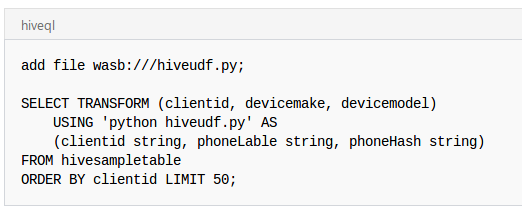

Fuente: [Use python UDF with Hive and Pig](https://docs.microsoft.com/en-us/azure/hdinsight/hadoop/python-udf-hdinsight)

El `add file` hace que se encuentre disponible para el cluster el archivo de python, el `transform ... using` permite que se ocupe la UDF indicando de qué archivo tiene que ir a buscar esta definición.

#### Hive en AWS/EMR

[Capítulo: Hive and Amazon Web Services de Programming Hive](http://shop.oreilly.com/product/0636920023555.do)

En EMR el nodo master tiene instalado un MySQL que es el que ocuparemos en Hive para ser su metastore, todos los datos que se encuentran en los nodos del clúster son borrados en cuanto decidimos terminar el clúster, esto incluye los datos del nodo master… y eso implica perder los esquemas alamacenados en el metastore… para dejar estos datos persistentes se pueden hacer 2 cosas:

1. Utilizar un metastore externo al proporcionado por el EMR: Esto requiere de hacer configuraciones al momento de instalar el Hive, es posible ocupar un RDS de Amazon ＼(＾O＾)／… esta es la mejor opción para compartir un metastore entre diferentes clústers EMR, o bien un mismo clúster EMR pero que ocupa diferentes versiones de Hive.
2. Proporcionar un script de inicio (*start-up*): En esta opción utilizaremos el metastore que tenemos por default en el clúster de EMR pero tenemos que proporcionar un script de inicio, este script puede ser *custom* o bien podemos ocupar `.hiverc` que es un script que ejecuta en automático el Hive CLI cuando inicia… si este script es proporcionado entonces en cada invocación del CLI se ejecutará, esto puede ser contraproducente al hacer *overhead* en las invocaciones pues solo requerimos de que se invoque una sola vez :(.

Esta segunda solución solo se recomienda cuando se tienen muy pocas tablas y particiones que cargar, de otra manera el tiempo de inicialización del clúster será cada vez mayor conforme el metastore va creciendo.

3. También es posible guardar un *backup* del metastore en S3 antes de terminar el clúster… aunque esta solución esta chunda -está muy mal visto entre los ingenieros de datos-

#### Hive en *Streaming*

Es posible ocupar Hive con datos en *streaming*, regresaremos a este punto cuando veamos *streaming* :)

### Hue

Hue es una interfaz gráfica open source que se ocupa para conectarse a Hive y Pig de manera más orgánica y fácil que ocupando solo la interfaz de EMR o solo el *shell* de Hive y Pig.

EMR viene con Hue instalado, solo que para ocuparlo tenemos que “habilitarlo” con los [siguientes pasos](https://docs.aws.amazon.com/emr/latest/ReleaseGuide/accessing-hue.html):

[figure not shown]

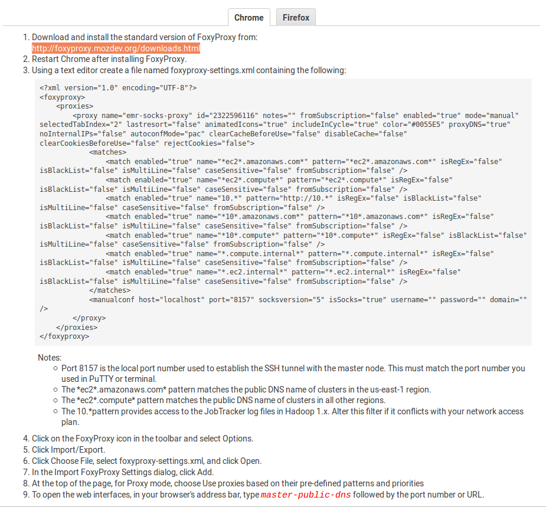

#### Ejemplos

Ocuparemos la base de datos de Northwind para “pasarla” a Hive y jugar con algunos queries.

1. Creareamos la base de datos para northwind (esquema) (con EMR)

```
create database if not exists northwind
location 's3://metodos-gran-escala/hive/northwind/';
```

2. Creamos las tablas products, orders, order_details y las “llenamos” con sus respectivos datos (con EMR)

```
drop database if exists northwind cascade;

create database if not exists northwind location "s3://metodos-gran-escala/hive/northwind/";

create external table if not exists northwind.products (productid smallint,
productname string,
supplierid smallint,
categoryid smallint,
quantityperunit string,
unitprice float,
unitsinstock smallint,
unitsonorder smallint,
reorderlevel smallint,
discontinued int)
ROW FORMAT DELIMITED FIELDS TERMINATED BY ','
LOCATION 's3://metodos-gran-escala/hive/northwind/products';

LOAD DATA INPATH 's3://metodos-gran-escala/products.csv' INTO table northwind.products;

create external table if not exists northwind.orders (
orderid smallint,
customerid string,
employeeid smallint,
orderdate timestamp,
requireddate timestamp,
shippeddate timestamp,
shipvia smallint,
freight float,
shipname string,
shipaddress string,
shipcity string,
shipregion string,
shippostalcode string,
shipcountry string)
ROW FORMAT DELIMITED FIELDS TERMINATED BY ','
LOCATION 's3://metodos-gran-escala/hive/northwind/orders';


LOAD DATA INPATH 's3://metodos-gran-escala/orders.csv'
INTO table northwind.orders;

create external table if not exists northwind.order_details (orderid smallint,
productid smallint,
unitprice float,
quantity smallint,
discount float)
row format delimited fields terminated by ','
location 's3://metodos-gran-escala/hive/northwind/orderdetails';

LOAD DATA INPATH 's3://metodos-gran-escala/order_details.csv'
INTO table northwind.order_details;
```

```
select od.productid, productname, count(*) as num
from orders o join order_details od
on o.orderid = od.orderid
join products p
on p.productid = od.productid
group by od.productid, productname
having count(*) > 50
order by num desc
limit 10;
```

#### Tarea 5

A entregar de manera individual el **12 marzo 2018** máximo 23:59:59 CST en tu carpeta `alumnos/nombre_apellido/tarea_5/`

**Ejercicio 1.** Con la base de datos de northwind que se encuentran en el [dropbox](https://www.dropbox.com/sh/qormkgqgt5o8zk3/AADNbqwqeXEfM_tNcieeX0B-a?dl=0):

1. ¿Cuántos “jefes” hay en la tabla empleados? ¿Cuáles son estos jefes: número de empleado, nombre, apellido, título, fecha de nacimiento, fecha en que iniciaron en la empresa, ciudad y país? (atributo `reportsto`, ocupa `explode` en tu respuesta)
2. ¿Quién es el segundo “mejor” empleado que más órdenes ha generado? (nombre, apellido, título, cuándo entró a la compañía, número de órdenes generadas, número de órdenes generadas por el mejor empleado (número 1))
3. ¿Cuál es el delta de tiempo más grande entre una orden y otra?

**Ejercicio 2.** Con los archivos de vuelos, aeropuertos y aerolíneas que están en el [dropbox](https://www.dropbox.com/sh/rdd78b7nofjb5vy/AAAwUm97baTusv5l8QY2ZAi2a?dl=0)

1. ¿Qué aerolíneas (nombres) llegan al aeropuerto “Honolulu International Airport”?
2. ¿En qué horario (hora del día, no importan los minutos) hay salidas del aeropuerto de San Francisco (“SFO”) a “Honolulu International Airport”?
3. ¿Qué día de la semana y en qué aerolínea nos conviene viajar a “Honolulu International Airport” para tener el menor retraso posible?
4. ¿Cuál es el aeropuerto con mayor tráfico de entrada?
5. ¿Cuál es la aerolínea con mayor retraso de salida por día de la semana?
6. ¿Cuál es la tercer aerolínea con menor retraso de salida los lunes (day of week = 2)?
7. ¿Cuál es el aeropuerto origen que llega a la mayor cantidad de aeropuertos destino diferentes?

Tu clúster se debe llamar `nombre_apellido`

¿Qué se entrega?

- RMD y html con los queries que ejecutaste para cada pregunta/inciso
- Los archivos de salida de Hive después de correr los scripts (puedes correrlos desde Hue)
- Imagen del *summary* de tu clúster

¿Qué se califica?

- No entregó RMD y html: -2
- No agregó imágenes: -2
- No agregó el código de cada script: -4
- No agregó archivos de salida del clúster (part-r-00000): -4
- Ejercicio 1:
  - a: 1
  - b: 1
  - c: 1
- Ejercicio 2:
  - a: 1
  - b: 1
  - c: 1
  - d: 1
  - e: 1
  - f: 1
  - g: 1

**Total: 10**

### Referencias

- [How to install Sqoop 1.4.6](https://hadoop7.wordpress.com/2017/09/05/installing-and-configuring-apache-sqoop-1-4-6/)
- [Sqoop user guide](http://sqoop.apache.org/docs/1.4.7/SqoopUserGuide.html)
- [Libro recomendado de Sqoop](https://www.safaribooksonline.com/library/view/apache-sqoop-cookbook/9781449364618/)
- [How to install Pig](http://pig.apache.org/docs/r0.17.0/start.html#Pig+Setup)
- [Libro recomendado de Pig](https://www.amazon.com.mx/Programming-Pig-Dataflow-Scripting-Hadoop-ebook/dp/B01N8TQ46A/ref=sr_1_1?ie=UTF8&qid=1518333194&sr=8-1&keywords=apache+pig+oreilly)
- [Pig cookbook](http://pig.apache.org/docs/r0.7.0/cookbook.html)
- [Pig tutorial](https://pig.apache.org/docs/r0.17.0/basic.html#flatten)
- [UDF DataFu](https://datafu.incubator.apache.org/blog/2012/01/10/introducing-datafu.html)
- [JavaDoc UDF piggybank](http://svn.apache.org/viewvc/pig/trunk/contrib/piggybank/java/src/main/java/org/apache/pig/piggybank/)
- [How to install Hive](https://hive.apache.org/downloads.html)
- [Libro Programming Hive](http://shop.oreilly.com/product/0636920023555.do)
- [Hive window functions and analytics](https://cwiki.apache.org/confluence/display/Hive/LanguageManual+WindowingAndAnalytics)
- [Configurar ssh tunel para ver el master de AWS](https://docs.aws.amazon.com/emr/latest/ManagementGuide/emr-ssh-tunnel.html)